# Análisis y caracterización de la Base de Datos CENSALUD para el Estudio Epidemiológico del Dengue en Zonas Vulnerables de San Salvador

Autor/a

Sulma Dubon Olmedo

Fecha de publicación

1 de noviembre de 2024

# Análisis de información y base de datos proporcionado por CENSALUD.

El objetivo es comprender y mejorar la estructura de la tabla de datos proporcionada por CENSALUD para el estudio epidemiológico del dengue en zonas vulnerables de San Salvador y que esta sea adecuada para el análisis en R.

En el Apéndice A. las Figuras Figura 1, Figura 2 y Figura 3 se muestra la base de datos utilizada por CENSALUD. La tabla contiene una estructura compleja para el análisis de datos, debido a la gran cantidad de variables (columnas) empleadas para la recopilación de información. Muchas de estas variables no están definidas claramente, ya que se presentan en forma de preguntas, lo que dificulta su tratamiento. Además, la base de datos contiene información redundante, algunas preguntas están representadas con columnas separadas para respuestas afirmativas y negativas, categorizadas como “Sí = 1” y “No = 2”. Esta organización, junto con la división en tablas por cada departamento, incrementa la complejidad del análisis.

## Pasos para mejorar la estructura de la tabla

Pasos:

- Unificación de datos

  La información del estudio se encuentra separada en diferentes tablas de excel por municipio, para unificar los datos se pasan a estructura tabular y se unen las tablas una sola matriz, se incorpora en una columna con el nombre del municipio.
- Eliminación de información irrelevante.

  La base de datos cuenta con información personal que no es relevante para el análisis de datos, se eliminaron las variables: Entrevistador, Dirección, Nombre del jefe de familia, Edad y numero de telefono.
- Estandarización y Simplificación de Variables

  Las preguntas largas fueron reemplazadas por nombres de variables concisos y descriptivos. En algunos casos, se modificaron el tipo de variable, valores, etc. En el apendice Apéndice B se muetra la tabla con sus variables y sus valores

**Código**

```r
if (!requireNamespace("flextable", quietly = TRUE)) {
  install.packages("flextable")
}
if (!requireNamespace("tidyr", quietly = TRUE)) {
  install.packages("tidyr")
}
if (!requireNamespace("writexl", quietly = TRUE)) {
  install.packages("writexl")
}
if (!requireNamespace("readxl", quietly = TRUE)) {
  install.packages("readxl")
}

# Cargar las bibliotecas
library(flextable)
library(tibble)
library(dplyr)
library(tidyr)
library(readxl)
library(writexl)
```

**Código**

```r
getwd()
```

```
[1] "C:/Users/HP/Desktop/UOC/SEMESTRE3/PRACTICAS/Proyecto_UES/CENSALUD/AnalisisBD"
```

**Código**

```r
Encuesta <- read_excel("EncuestaCompleta.xlsx")
dimensiones <- dim(Encuesta)
```

La tabla con las modificaciones tienen un total de 87 columnas, que son el total de variables a analizar en diferentes áreas, y 21 filas que corresponde al número de muestras tomadas.

## Normalización de Datos Faltantes (NULL o NA)

Otro paso importante en el análisis de datos es la a normalización de los valores faltantes, que normalmente conoemos como: NULL, NA, garantizando que todos los valores faltantes estén correctamente identificados.

**Código**

```r
# Normalizar los datos: convertir "" y "NA" en NA en variables categóricas y numéricas
Encuesta <- Encuesta %>%
  mutate(across(where(is.character), ~ na_if(.x, "") %>% na_if("NA"))) %>% # Para variables de texto
  mutate(across(where(is.factor), ~ as.character(.x) %>% na_if("") %>% na_if("NA") %>% as.factor())) %>% # Para factores
  mutate(across(where(is.numeric), ~ ifelse(.x %in% c("", "NA"), NA, .x))) # Para numéricas

# Verificar el tipo y resumen de valores NA
resumen_na <- sapply(Encuesta, function(col) sum(is.na(col)))

# Imprimir resumen de valores NA
cat("Resumen de valores NA por columna:\n")
```

```
Resumen de valores NA por columna:
```

**Código**

```r
print(resumen_na)
```

```
           ID         Fecha     Municipio      Coor_Lat     Coor_Long
            0             0             0             0             0
     CncTrans       CncSint       CncCont       FamDiag    DiagDengue
            0             0             0             0            13
     DiagZika      DiagChik       FamHosp    HospDengue      HospZika
           13            13            13            17            17
     HospChik       MetDiag       Caso_6m       AtenMed      PruebLab
           17            13             0             5             5
      AutoMed        MedNat       BrotVec        MedVec      Mosq_uso
            5             5             0            15             0
   Mosq_Insec     Mosq_Peri       MosqTds         MFN<5        MFN5-7
           14            14            14            14            14
     MFA18-40        MFA>40      MosqAguj     MsqFrcStd     Malla_Uso
           14            14            14            14             0
    Repel_Uso        Charla       Fum_Com      Fum_frec     Ult_Vis_A
            0             0             0             6             6
    Fum_Hogar     Fum_MotNo      Fum_Cree Frec_Limp_Dep      Abat_Uso
            6            20             0             0             0
   Abat_tiemp      Inf_prev      Inf_Foll      Inf_char    Inf_tv/rad
           16             0             2             2             2
   Inf_redsoc      inf_otro      Resp_Soc      Resp_Alc   Resp_MINSAL
            2             2             0             0             0
          N<5         N5-17        A18_40          A>40         Embar
            0             0             0             0             0
    ParedTipo   RepelloTipo     TechoTipo          Gote     SueloTipo
            0             0             0             0             0
   EstrucAdic      AguaTipo     FrecRecAg     AlmBarril        AlmCub
            0             0            20             0             0
      AlmPila       AlmOtro       AlmNing       CubTipo       ZancViv
            0             0             0             0             0
      LarvViv        RecBrl        RecCub       RecPila        RecMct
            0             1             1             1             1
     RecLlnts      RecOtros       RecNing         H_Aeg         M_Aeg
            1             1             0             1             1
       H_albo        M_albo
            1             1
```

## Asignar el tipo de dato correspondiente a cada variable en R.

Un paso muy importante para el analisis de datos es caracterizar cada tipo de datos, esto nos permite utilizar diferentes tecnicas para su análisis.

**Código**

```r
# Asignar los tipos de datos a las variables
Encuesta$ID <- as.character(Encuesta$ID)
Encuesta$Fecha <- as.Date(Encuesta$Fecha, format="%Y-%m-%d")
Encuesta$Municipio <- as.character(Encuesta$Municipio)
Encuesta$Coor_Lat <- as.character(Encuesta$Coor_Lat)
Encuesta$Coor_Long <- as.character(Encuesta$Coor_Long)

# Variables categóricas (Sí=1, No=0)
categorical_vars <- c(
  "CncTrans", "CncSint", "CncCont", "FamDiag", "DiagDengue",
  "DiagZika", "DiagChik", "FamHosp", "HospDengue", "HospZika",
  "HospChik", "MetDiag", "Caso_6m", "AtenMed", "PruebLab",
  "AutoMed", "MedNat", "BrotVec", "MedVec", "Mosq_uso",
  "Mosq_Insec", "Mosq_Peri", "MosqTds", "MFN<5", "MFN5-7",
  "MFA18-40", "MFA>40", "MosqAguj", "MsqFrcStd", "Malla_Uso",
  "Repel_Uso", "Charla", "Fum_Com", "Fum_frec", "Ult_Vis_A",
  "Fum_Hogar", "Fum_MotNo", "Fum_Cree", "Frec_Limp_Dep",
  "Abat_Uso", "Abat_tiemp", "Inf_prev", "Inf_Foll", "Inf_char",
  "Inf_tv/rad", "Inf_redsoc", "inf_otro", "Resp_Soc", "Resp_Alc",
  "Resp_MINSAL", "ParedTipo", "RepelloTipo", "TechoTipo", "Gote",
  "SueloTipo", "EstrucAdic", "AguaTipo", "FrecRecAg", "AlmBarril",
  "AlmCub", "AlmPila", "AlmOtro", "AlmNing", "CubTipo", "ZancViv",
  "LarvViv", "RecBrl", "RecCub", "RecPila", "RecMct", "RecLlnts",
  "RecOtros", "H_Aeg", "M_Aeg", "H_albo", "M_albo"
)

# Convertir todas las variables categóricas a factor
Encuesta[categorical_vars] <- lapply(Encuesta[categorical_vars], as.factor)

# Variables numéricas
numeric_vars <- c("N<5", "N5-17", "A18_40", "A>40", "Embar")

# Convertir las variables numéricas
Encuesta[numeric_vars] <- lapply(Encuesta[numeric_vars], as.integer)
```

La estructura de la base de datos esta completada y lista para su análisis, presentamos una tabla de datos con información esencial para comprender las características de cada variable

**Código**

```r
tipo_datos <- tibble(
  Variable = names(Encuesta),
  Tipo = sapply(Encuesta, function(x) class(x)[1]),  # Tipo de dato
  Unicos = sapply(Encuesta, function(x) length(unique(x))),  # Valores únicos
  NA_Conteo = sapply(Encuesta, function(x) sum(is.na(x))),  # Cantidad de valores NA
  Primeros_Valores = sapply(Encuesta, function(x) paste(head(x, 3), collapse = ", "))  # Primeros  valores
)
# Crear la tabla
tabla_flex <- flextable(tipo_datos)

# Ajustar la distribución para que ocupe todo el ancho de la página
tabla_flex <- autofit(tabla_flex)

tabla_flex
```

| Variable | Tipo | Unicos | NA_Conteo | Primeros_Valores |
| --- | --- | --- | --- | --- |
| ID | character | 21 | 0 | 06-17-00-11, 06-17-00-12, 06-17-00-13 |
| Fecha | Date | 4 | 0 | 2024-08-09, 2024-08-09, 2024-08-09 |
| Municipio | character | 2 | 0 | Soyapango, Soyapango, Soyapango |
| Coor_Lat | character | 19 | 0 | 13°42.6110'N, 13°42.6120'N, 13°42.3700'N |
| Coor_Long | character | 21 | 0 | 89°8.3400'O, 89°8.3390'O, 89°8.2000'O |
| CncTrans | factor | 2 | 0 | 1, 1, 1 |
| CncSint | factor | 2 | 0 | 1, 1, 1 |
| CncCont | factor | 2 | 0 | 0, 0, 0 |
| FamDiag | factor | 2 | 0 | 1, 0, 1 |
| DiagDengue | factor | 3 | 13 | 1, NA, 1 |
| DiagZika | factor | 2 | 13 | 0, NA, 0 |
| DiagChik | factor | 3 | 13 | 0, NA, 0 |
| FamHosp | factor | 3 | 13 | 1, NA, 1 |
| HospDengue | factor | 3 | 17 | 1, NA, 1 |
| HospZika | factor | 2 | 17 | 0, NA, 0 |
| HospChik | factor | 2 | 17 | 0, NA, 0 |
| MetDiag | factor | 3 | 13 | 1, NA, 1 |
| Caso_6m | factor | 2 | 0 | 1, 0, 1 |
| AtenMed | factor | 3 | 5 | 1, 1, 1 |
| PruebLab | factor | 3 | 5 | 0, 0, 0 |
| AutoMed | factor | 3 | 5 | 0, 0, 0 |
| MedNat | factor | 2 | 5 | 0, 0, 0 |
| BrotVec | factor | 3 | 0 | 1, 1, 1 |
| MedVec | factor | 4 | 15 | 1, 1, 3 |
| Mosq_uso | factor | 2 | 0 | 1, 0, 0 |
| Mosq_Insec | factor | 2 | 14 | 0, NA, NA |
| Mosq_Peri | factor | 3 | 14 | 1, NA, NA |
| MosqTds | factor | 2 | 14 | 1, NA, NA |
| MFN<5 | factor | 2 | 14 | 0, NA, NA |
| MFN5-7 | factor | 2 | 14 | 0, NA, NA |

[output cut: 57 more lines]

Finalmente guardamos la nueva base de datos con todas las modificaciones en formato .csv

**Código**

```r
# Guardar la base de datos normalizada en un archivo CSV
write.csv(Encuesta, "Encuesta_Normalizada.csv", row.names = FALSE)

cat("La base de datos normalizada se guardó como 'Encuesta_Normalizada.csv'.")
```

```
La base de datos normalizada se guardó como 'Encuesta_Normalizada.csv'.
```

## Conclusiones

1. **Optimización de la Base de Datos para el Análisis Epidemiológico**  
   La unificación de datos provenientes de múltiples tablas y la eliminación de redundancias permitió transformar una base de datos compleja y fragmentada en una estructura más manejable y adecuada para el análisis en R. Esto facilita la identificación de patrones y tendencias epidemiológicas en las zonas vulnerables de San Salvador.
2. **Reducción de la Complejidad en la Organización de Variables**  
   El proceso de estandarización de las preguntas y la simplificación de nombres de variables mejora la legibilidad de la tabla, lo que a su vez reduce errores y simplifica la interpretación. Este paso es clave para realizar análisis más eficientes y menos propensos a confusiones.
3. **Eliminación de Información Irrelevante como Práctica Ética y Técnica**  
   La eliminación de datos personales, como nombres, direcciones y números de teléfono, no solo protege la privacidad de los participantes, sino que también reduce el tamaño de la base de datos y elimina ruido innecesario. Esto permite centrarse exclusivamente en las variables de interés para el estudio.
4. **Homogeneización de las Tablas por Departamentos y Municipios**  
   La consolidación de tablas separadas en una única estructura tabular con un identificador de municipio simplificó el proceso de análisis multivariable. Este enfoque garantiza que los resultados sean consistentes y permite comparaciones regionales más claras.
5. **Contribución al Estudio Epidemiológico del Dengue**  
   Estas mejoras aseguran que los datos recopilados puedan utilizarse de manera más efectiva para identificar factores de riesgo y poblaciones vulnerables. Una base de datos organizada y clara es fundamental para realizar análisis estadísticos confiables y para diseñar estrategias de intervención más precisas.
6. **Facilitación del Uso de Herramientas de Análisis en R**  
   La reestructuración de la base de datos se orientó específicamente hacia su compatibilidad con R, lo que permitirá utilizar funciones avanzadas para análisis estadístico, visualización de datos y modelado predictivo. Esto incrementa el potencial del estudio para generar hallazgos útiles y basados en evidencia.
7. **Impacto en la Toma de Decisiones para la Salud Pública**  
   Este trabajo no solo mejora la calidad del análisis epidemiológico, sino que también proporciona un modelo de gestión y estructuración de datos que puede replicarse en otros estudios. Esto fortalece la capacidad de CENSALUD para realizar investigaciones informadas y de alto impacto en el campo de la salud pública.

En conjunto, estas acciones no solo hacen que los datos sean más utilizables, sino que también mejoran la reproducibilidad y la claridad del estudio, lo que permite un análisis epidemiológico más profundo y efectivo del dengue en áreas vulnerables.

# Apéndice A: Base de Datos CENSALUD

En esta sección se presentan las figuras que muestran la tabla completa utilizada para el estudio epidemiológico del dengue en zonas vulnerables de San Salvador.

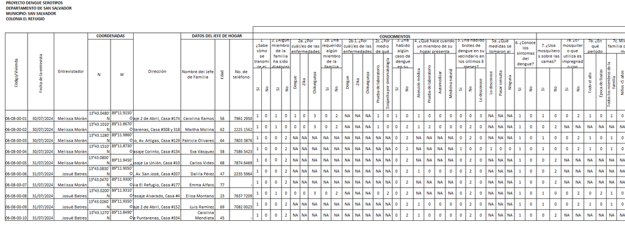

Figura 1: Parte 1 de la base de datos CENSALUD

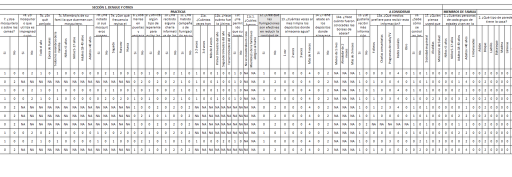

Figura 2: Parte 2 de la base de datos CENSALUD

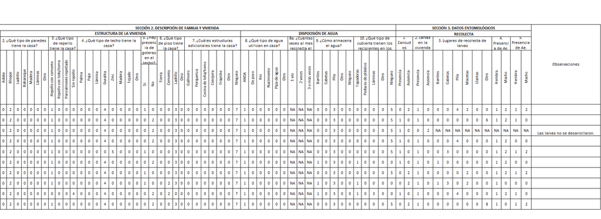

Figura 3: Parte 3 de la base de datos CENSALUD

# Apéndice B: Tabla de variables, descripcion y tipo de datos

**Código**

```r
# Asignación de variables

variable_descripcion <- data.frame(
  Variable = c('ID', 'Fecha', 'Municipio', 'Coor_Lat', 'Coor_Long',
          'CncTrans', 'CncSint', 'CncCont', 'FamDiag', 'DiagDengue',
        'DiagZika', 'DiagChik', 'FamHosp', 'HospDengue','HospZika',
        'HospChik', 'MetDiag', 'Caso_6m', 'AtenMed', 'PruebLab',
        'AutoMed', 'MedNat', 'BrotVec', 'MedVec', 'Mosq_uso',
        'Mosq_Insec', 'Mosq_Peri', 'Mosqtds', 'MFN<5', 'MFN5-7',
        'MFA1840', 'MFA>40', 'Mosq_Aguj', 'Mosq_frec_est',
        'Malla_Uso', 'Repel_Uso', 'Charla', 'Fum_Camp', 'Fum_frec',
        'Ult_Vis_A', 'Fum_Hogar', 'Fum_MotNo', 'Fum_Cree',
        'Frec_Limp_Dep', 'Abat_Uso', 'Abat_tiemp', 'Inf_prev',
        'Inf_Foll', 'Inf_char', 'Inf_tv/rad', 'Inf_redsoc',
        'inf_otro', 'Resp_Soc', 'Resp_Alc', 'Resp_MINSAL', 'N<5',
        'N5-17', 'A18_40', 'A>40', 'Embar', 'ParedTipo',
        'RepelloTipo', 'TechoTipo', 'Gote', 'SueloTipo', 'EstrucAdic',
        'AguaTipo', 'FrecRecAg', 'AlmBarril', 'AlmCub', 'AlmPila',
        'AlmOtro', 'AlmNing', 'CubTipo', 'ZancViv', 'LarvViv',
        'RecBrl', 'RecoCub', 'RecPil', 'RecMct', 'RecLlnts', 'RecOtr',
         'H_Aeg', 'M_Aeg', 'H_albo', 'M_albo'
),
  Descripcion = c('Codigo vivienda', 'Fecha encuesta', 'Municipio',
          'Coordenada latitud', 'Coordenada longitud', 'Conocimiento
          transmisión del dengue', 'Conocimiento síntomas del
          dengue', 'Conocimiento control poblaciones zancudos',
          'Diagnóstico previo de dengue, zika o chikungunya en la
          familia', 'Diagnóstico de dengue', 'Diagnóstico de zika',
          'Diagnóstico de chikungunya', 'Familia Requiere de
          hospitalización', 'Hospitalización por dengue',
          'Hospitalización por zika', 'Hospitalización por
          chikungunya', 'Método de diagnóstico', 'Caso de dengue en
          los últimos 6 meses', 'Atención médica por sospecha de
          dengue', 'Prueba de laboratorio por sospecha de dengue',
          'Automedicación por sospecha de dengue', 'Uso de medicina
          natural por sospecha de dengue', 'Conoce brotes de dengue
          en vecindario  últimos 6 meses', 'Medidas tomadas en el
          vecindario ante brotes de dengue', 'Uso de mosquiteros
          sobre las camas', 'Uso de mosquiteros impregnados con
          insecticida', 'Período de uso de mosquiteros', 'Uso de
          mosquiteros en todos los grupos de edad', 'Uso de
          mosquitero familiares menores de 5 años', 'Uso mosquitero
          familiares entre 5 y 7 años', 'Uso mosquitero familiares
          entre 18 y 40 años', 'Uso mosquitero familiares mayores de
          40 años', 'Mosquiteros poseen agujeros', 'Frecuencia revisa
          el estado del mosquitero', 'Usa mallas en puertas y
          ventanas', 'Utiliza algún tipo de repelente', 'Ha recibido
          alguna charla informativa de las autoridades de salud sobre
          cómo prevenir el dengue', 'Campañas de fumigación en su
          comunidad en los últimos 6 meses', 'Frecuencia de las
          campañas de fumigación en los últimos 6 meses', 'Cuando fue
          la última visita por parte de las autoridades de salud u
          otras entidades para fumigar su casa', 'Permitió que su
          hogar sea fumigado', 'Motivo por el que no permitió que se
          fumigara', 'Cree que las fumigaciones son efectivas en
          reducir la cantidad de zancudos', 'Frecuencia de limpieza
          los depósitos donde se almacena agua en el mes', 'Uso de
          abate en los depósitos donde almacena agua', 'Hace cuánto
          fueron colocadas las bolsas de abate', 'Recibir más
          información sobre cómo prevenir el dengue', 'Recibir
          información en folleto', 'Recibir información en charlas
          comunitarias', 'Recibir información en programas tv/radio',
          'Recibir información por redes sociales', 'Recibir
          información en otros medios', 'Responsabilidad del control
          del dengue la sociedad en general', 'Responsabilidad del
          control del dengue Alcaldías', 'Responsabilidad del control
          del dengue Ministerio de salud', 'Niños menores de 5 años',
          'Niños entre 5 y 17 años', 'Adultos entre 18 y 40 años',
          'Adultos mayores de cuarenta', 'Mujeres embarazadas', 'Tipo
          de paredes de la vivienda', 'Tipo de repello de la
          vivienda', 'Tipo de techo de la vivienda', 'Presencia de
          goteras en el techo', 'Tipo de piso de la vivienda',
          'Estructuras adicionales en la vivienda', 'Tipo de agua
          utilizada en casa', 'Frecuencia de recolección de agua',
          'Almacena en barriles', 'Almacena en cubetas', 'Almacena en
          pila', 'Almacena en otro', 'No almacena', 'Tipo de cubierta
          en los recipientes de almacenamiento de agua', 'Presencia
          de zancudos adultos en la vivienda', 'Presencia de larvas
          en la vivienda', 'Recolecta larvas en barril', 'Recolecta
          larvas en cubetas', 'Recolecta larvas en pila', 'Recolecta
          larvas en macetas', 'Recolecta larvas en llantas',
          'Recolecta larvas en otros', 'Presencia de hembra aegypti
          en la vivienda', 'Presencia de macho aegypti en la
          vivienda', 'Presencia de hembra Albopictus', 'Presencia de
          macho Albopictus'
),
  Tipo_de_Variable = c('carácter', 'fecha', 'carácter', 'Coordenadas DMS',
                    'Coordenadas DMS', 'Categórica (Sí=1, No=0)',
                    'Categórica (Sí=1, No=0)', 'Categórica (Sí=1, No=0)',
                    'Categórica (Sí=1, No=0)', 'Categórica (Sí=1, No=0)',
                    'Categórica (Sí=1, No=0)', 'Categórica (Sí=1, No=0)',
                    'Categórica (Sí=1, No=0)', 'Categórica (Sí=1, No=0)',
                    'Categórica (Sí=1, No=0)', 'Categórica (Sí=1, No=0)',
                    'Categórica (Prueba de laboratorio=1, Sospechas por
                    sintomatología=2)', 'Categórica (Sí=1, No=0)',
                    'Categórica (Sí=1, No=0)', 'Categórica (Sí=1, No=0)',
                    'Categórica (Sí=1, No=0)', 'Categórica (Sí=1, No=0)',
                    'Categórica (Sí=1, No=0, Desconoce=2)','Categórica
                    (Desconoce=1, Pasar consulta=2, Ninguna=3)',
                    'Categórica (Sí=1, No=0)', 'Categórica (Sí=1, No=0)',
                    'Categórica (Todo el año=1, Época de lluvias=2)',
                    'Categórica (Sí=1, No=0)', 'Categórica (Sí=1, No=0)',
                    'Categórica (Sí=1, No=0)', 'Categórica (Sí=1, No=0)',
                    'Categórica (Sí=1, No=0)', 'Categórica (Sí=1, No=0)',
                    'Categorica (Seguido=1, Rara vez=2, Nunca=3)',
                    'Categórica (Sí=1, No=0)', 'Categórica (Sí=1, No=0)',
                    'Categórica (Sí=1, No=0)', 'Categórica (Sí=1, No=0)',
                    'Categorica (1-2 veces=1, 3-4 veces=2, Más de 4
                    veces=3)', 'Categorica (1er trimestre=1, 2do
                    trimestre=2, 3er trimestre=3)', 'Categórica (Sí=1,
                    No=0)', 'Categórica (No se encontraba en casa=1,
                    Alergicos en la familia=2)', 'Categórica (Sí=1,
                    No=0)', 'Categorica (1 vez=1, 2 veces=2, 3 veces=3,
                    más de 4 veces=4)', 'Categórica (Sí=1, No=0)',
                    'Categorica (menos de 1 mes=1, alrededor de 2 meses=2,
                    más de 3 meses=3)', 'Categórica (Sí=1, No=0)',
                    'Categórica (Sí=1, No=0)', 'Categórica (Sí=1, No=0)',
                    'Categórica (Sí=1, No=0)', 'Categórica (Sí=1, No=0)',
                    'Categórica (Sí=1, No=0)', 'Categórica (Sí=1, No=0)',
                    'Categórica (Sí=1, No=0)', 'Categórica (Sí=1, No=0)',
                    'Numérica', 'Numérica', 'Numérica', 'Numérica',
                    'Numérica', 'Categórica (Adobe=1, Bloque=2,
                    Ladrillo=3, Nahareque=4, Madera=5, Láminas=6,
                    Otro=7)', 'Categórica (Cemento=1, Lodo/tierra=2,
                    Parcialmente repellado=3, Sin repello=4)', 'Categórica
                    (Palma=1, Paja=2, Lámina=3, Duralita=4, Zinc=5,
                    Madera=6, Tejado=7, Otro=8)', 'Categórica (Sí=1,
                    No=0)', 'Categórica (Tierra=1, Cemento=2, Ladrillo=3,
                    Otro=4)', 'Categórica (Gallinero=1, Porqueriza=2,
                    Cocina de leña/horno=3, Conejera=4, Trapiche=5,
                    Otro=6, Ninguno=7)', 'Categórica (ANDA=1, De pozo=2,
                    Río=3, Nacimiento=4, Pipa de agua=5, Otro=6)',
                    'Categórica (1 vez=1, 2 veces=2, 3 o más veces=3)',
                    'Categórica (Sí=1, No=0)', 'Categórica (Sí=1, No=0)',
                    'Categórica (Sí=1, No=0)', 'Categórica (Sí=1, No=0)',
                    'Categórica (Sí=1, No=0)', 'Categórica (Ninguno=1,
                    Tapaderas=2, Pedazos de plástico=3, Láminas=4,
                    Otro=5)', 'Categórica (Sí=1, No=0)', 'Categórica
                    (Sí=1, No=0)', 'Categórica (Sí=1, No=0)', 'Categórica
                    (Sí=1, No=0)', 'Categórica (Sí=1, No=0)', 'Categórica
                    (Sí=1, No=0)', 'Categórica (Sí=1, No=0)', 'Categórica
                    (Sí=1, No=0)', 'Categórica (Sí=1, No=0', 'Categórica
                    (Sí=1, No=0', 'Categórica (Sí=1, No=0)', 'Categórica
                    (Sí=1, No=0)'
  )
)
```

**Código**

```r
# Cargar las librerías necesarias
library(knitr)
library(kableExtra)
# Crear la tabla
variable_descripcion %>%
  kable(
    caption = "Tabla de Descripción de Variables",
    booktabs = TRUE,
    longtable = TRUE,
    align = "lll"  # Alinear las tres columnas a la izquierda
  ) %>%
  kable_styling(
    latex_options = c("scale_down", "repeat_header", "hold_position")
  ) %>%
  column_spec(2, width = "6cm") %>%  # Ajustar el ancho de la columna 2
  column_spec(3, width = "6cm")      # Ajustar el ancho de la columna 3
```

Tabla de Descripción de Variables

| Variable | Descripcion | Tipo_de_Variable |
| --- | --- | --- |
| ID | Codigo vivienda | carácter |
| Fecha | Fecha encuesta | fecha |
| Municipio | Municipio | carácter |
| Coor_Lat | Coordenada latitud | Coordenadas DMS |
| Coor_Long | Coordenada longitud | Coordenadas DMS |
| CncTrans | Conocimiento transmisión del dengue | \|Categórica (Sí=1, No=0) |
| CncSint | Conocimiento síntomas del dengue | \|Categórica (Sí=1, No=0) |
| CncCont | Conocimiento control poblaciones zancudos | Categórica (Sí=1, No=0) |
| FamDiag | Diagnóstico previo de dengue, zika o chikungunya en la familia | \|Categórica (Sí=1, No=0) |
| DiagDengue | Diagnóstico de dengue | Categórica (Sí=1, No=0) |
| DiagZika | Diagnóstico de zika | Categórica (Sí=1, No=0) |
| DiagChik | Diagnóstico de chikungunya | Categórica (Sí=1, No=0) |
| FamHosp | Familia Requiere de hospitalización | \|Categórica (Sí=1, No=0) |
| HospDengue | Hospitalización por dengue | Categórica (Sí=1, No=0) |
| HospZika | Hospitalización por zika | Categórica (Sí=1, No=0) |
| HospChik | Hospitalización por chikungunya | \|Categórica (Sí=1, No=0) |
| MetDiag | Método de diagnóstico | Categórica (Prueba de laboratorio=1, Sospechas por sintomatología=2) |
| Caso_6m | Caso de dengue en los últimos 6 meses | \|Categórica (Sí=1, No=0) |
| AtenMed | Atención médica por sospecha de dengue | \|Categórica (Sí=1, No=0) |
| PruebLab | Prueba de laboratorio por sospecha de dengue | Categórica (Sí=1, No=0) |
| AutoMed | Automedicación por sospecha de dengue | Categórica (Sí=1, No=0) |
| MedNat | Uso de medicina natural por sospecha de dengue | \|Categórica (Sí=1, No=0) |
| BrotVec | Conoce brotes de dengue en vecindario últimos 6 meses | \|Categórica (Sí=1, No=0, Desconoce=2) |
| MedVec | Medidas tomadas en el vecindario ante brotes de dengue | \|Categórica (Desconoce=1, Pasar consulta=2, Ninguna=3) |
| Mosq_uso | Uso de mosquiteros sobre las camas | \|Categórica (Sí=1, No=0) |
| Mosq_Insec | Uso de mosquiteros impregnados con insecticida | \|Categórica (Sí=1, No=0) |
| Mosq_Peri | Período de uso de mosquiteros | Categórica (Todo el año=1, Época de lluvias=2) |
| Mosqtds | Uso de mosquiteros en todos los grupos de edad | \|Categórica (Sí=1, No=0) |
| MFN<5 | Uso de mosquitero familiares menores de 5 años | \|Categórica (Sí=1, No=0) |
| MFN5-7 | Uso mosquitero familiares entre 5 y 7 años | \|Categórica (Sí=1, No=0) |

[output cut: 56 more lines]